# Projekt 1

arek

2022-05-10

```r
library(lmtest)
```

```r
library(ggplot2)
library(GGally)
library(dplyr)
library(lessR)
library(tidyverse)
library(Hmisc)
library(jmuOutlier)
library(car)
```

## 1.

# a)

Wczytanie i obejrzenie danych

```r
file <- 'people.tab.csv'
df <- read.csv(file,sep = "\t")

head(df)
```

```
##   wiek waga wzrost plec stan_cywilny liczba_dzieci      budynek wydatki
## 1   25 61.7 121.12 <NA>        FALSE             2         loft 1662.91
## 2   37 63.9 145.00    M         TRUE             6 wielka_plyta 4041.86
## 3   41 50.2 145.03    K         TRUE             2   apartament 3853.45
## 4   43 72.4 179.90    M        FALSE             1 wielka_plyta 2398.88
## 5   26 78.4 163.91    M        FALSE             1   apartament 2344.45
## 6   49 59.4 151.86    K         TRUE             2         loft 1967.87
##   oszczednosci
## 1        23.44
## 2        96.84
## 3       312.68
## 4       447.43
## 5       -78.23
## 6      1241.98
```

```r
str(df)
```

```
## 'data.frame':    500 obs. of  9 variables:
##  $ wiek         : int  25 37 41 43 26 49 27 49 38 33 ...
##  $ waga         : num  61.7 63.9 50.2 72.4 78.4 59.4 67.5 82.3 64.1 77.4 ...
##  $ wzrost       : num  121 145 145 180 164 ...
##  $ plec         : chr  NA "M" "K" "M" ...
##  $ stan_cywilny : logi  FALSE TRUE TRUE FALSE FALSE TRUE ...
##  $ liczba_dzieci: int  2 6 2 1 1 2 1 0 5 2 ...
##  $ budynek      : chr  "loft" "wielka_plyta" "apartament" "wielka_plyta" ...
##  $ wydatki      : num  1663 4042 3853 2399 2344 ...
##  $ oszczednosci : num  23.4 96.8 312.7 447.4 -78.2 ...
```

Podsumowanie danych

```r
df$plec <-as.factor(df$plec)
df$budynek <-as.factor(df$budynek)
df$stan_cywilny <-as.factor(df$stan_cywilny)

summary(df)
```

```
##       wiek            waga            wzrost        plec     stan_cywilny
##  Min.   :17.00   Min.   : 45.20   Min.   :113.6   K   :239   FALSE:327
##  1st Qu.:33.00   1st Qu.: 59.20   1st Qu.:155.6   M   :223   TRUE :173
##  Median :39.00   Median : 67.50   Median :169.0   NA's: 38
##  Mean   :39.48   Mean   : 68.03   Mean   :168.2
##  3rd Qu.:45.00   3rd Qu.: 75.60   3rd Qu.:180.1
##  Max.   :72.00   Max.   :107.20   Max.   :235.2
##  liczba_dzieci            budynek       wydatki        oszczednosci
##  Min.   :0.000   apartament   : 54   Min.   : 524.9   Min.   :-685.68
##  1st Qu.:0.750   jednorodzinny:187   1st Qu.:1807.0   1st Qu.:  74.52
##  Median :1.000   kamienica    :105   Median :2489.9   Median : 402.22
##  Mean   :1.558   loft         : 54   Mean   :2511.7   Mean   : 478.60
##  3rd Qu.:2.000   wielka_plyta :100   3rd Qu.:3084.5   3rd Qu.: 802.73
##  Max.   :6.000                       Max.   :5574.6   Max.   :3503.90
```

```r
df.nonan <- na.omit(df)
```

Mamy 500 obserwacji, 6 zmiennych ilościowych i 3 jakościowe. Pośród zmiennych ilościowych mamy 1 zmienną dyskretną (liczba_dzieci) i 5 ciągłych, z kolei mamy 3 zmienne kategorialne nominalne (płeć, stan_cywilny i budynek), nie ma zmiennych kategorialnych porządkowych.

# b)

Zależności w zmiennych objaśniających. Uwaga: Ze wględu na to, że liczba_dzeci jest zmienną dyskretną, to tę zmienną rozpatrzymy osobno.

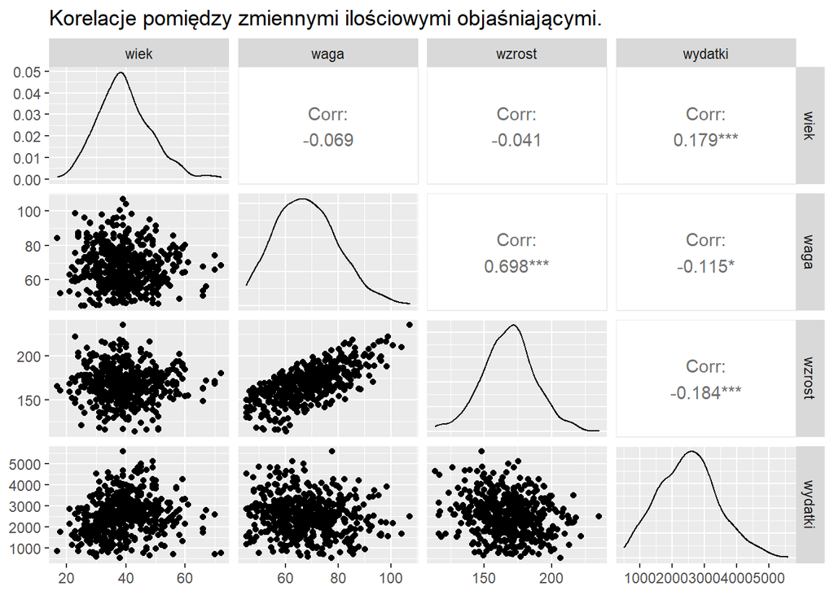

```r
ggpairs(df,columns = ,c('wiek','waga','wzrost','wydatki'), title ="Korelacje pomiędzy zmiennymi ilościowymi objaśniającymi.")
```

Na podstawie wyników widzimy, że skorelowane zmienne to: wydatki i wiek (corr = 0.179, znikoma korelacja), wydatki i wzrost (corr = -0.184, znikoma korelacja), wzrost i waga (corr = 0.698, średnia korelacja) oraz w zależności od poziomu istotności wydatki i waga (corr = -0.115, znikoma korelacja). W kontekście pozostałych par zmiennych, na podstawie naszych danych, nie możemy stwierdzić czy korelacja jest różna od 0.

Z uwagi na no, że liczba_dzeci jest zmienną dyskretną, to lepszą opcją będzie test korelacji Kendella.

```r
columns.totest <- c("wiek","waga","wzrost","wydatki")

cor.liczba_dzieciVSwiek <-  cor.test(df$liczba_dzieci, df$wiek, method = c("kendall"))
cor.liczba_dzieciVSwaga <-  cor.test(df$liczba_dzieci, df$waga, method = c("kendall"))
cor.liczba_dzieciVSwzrost <-  cor.test(df$liczba_dzieci, df$wzrost, method = c("kendall"))
cor.liczba_dzieciVSwydatki <-  cor.test(df$liczba_dzieci, df$wydatki, method = c("kendall"))

cor.liczba_dzieciVSwiek
```

```
##
##  Kendall's rank correlation tau
##
## data:  df$liczba_dzieci and df$wiek
## z = 0.16784, p-value = 0.8667
## alternative hypothesis: true tau is not equal to 0
## sample estimates:
##         tau
## 0.005620711
```

```r
cor.liczba_dzieciVSwaga
```

```
##
##  Kendall's rank correlation tau
##
## data:  df$liczba_dzieci and df$waga
## z = -0.88469, p-value = 0.3763
## alternative hypothesis: true tau is not equal to 0
## sample estimates:
##         tau
## -0.02919441
```

```r
cor.liczba_dzieciVSwzrost
```

```
##
##  Kendall's rank correlation tau
##
## data:  df$liczba_dzieci and df$wzrost
## z = -0.64376, p-value = 0.5197
## alternative hypothesis: true tau is not equal to 0
## sample estimates:
##         tau
## -0.02122175
```

```r
cor.liczba_dzieciVSwydatki
```

```
##
##  Kendall's rank correlation tau
##
## data:  df$liczba_dzieci and df$wydatki
## z = 14.034, p-value < 0.00000000000000022
## alternative hypothesis: true tau is not equal to 0
## sample estimates:
##       tau
## 0.4626023
```

Na podstawie powyższych wyników widzimy, że liczba_dzieci jest skorelowana z wydatkami ( corr = 0.46, niska korelacja). W kontekście pozostałych par zmiennych, na podstawie naszych danych, nie możemy stwierdzić czy korelacja jest różna od 0.

Przejdźmy teraz do zmiennych jakościowych…

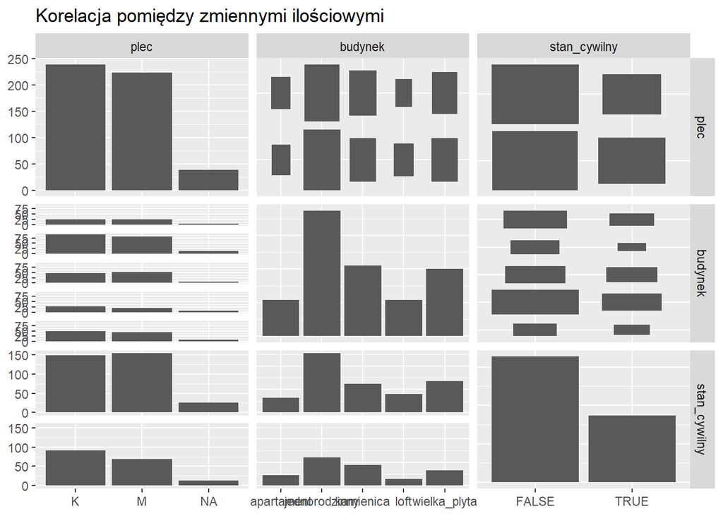

```r
ggpairs(columns = c('plec','budynek','stan_cywilny'), data = df, title = "Korelacja pomiędzy zmiennymi ilościowymi")
```

Przeprowadźmy testy

```r
ind.plecVSstan_cywilny <- fisher.test(df$plec, df$stan_cywilny)
ind.plecVSbudynek <- chisq.test(df$plec, df$budynek)
ind.budynekVSstan_cywilny <- chisq.test(df$budynek, df$stan_cywilny)

ind.plecVSstan_cywilny
```

```
##
##  Fisher's Exact Test for Count Data
##
## data:  df$plec and df$stan_cywilny
## p-value = 0.1179
## alternative hypothesis: true odds ratio is not equal to 1
## 95 percent confidence interval:
##  0.4859847 1.0911057
## sample estimates:
## odds ratio
##  0.7292089
```

```r
ind.plecVSbudynek
```

```
##
##  Pearson's Chi-squared test
##
## data:  df$plec and df$budynek
## X-squared = 1.4097, df = 4, p-value = 0.8425
```

```r
ind.budynekVSstan_cywilny
```

```
##
##  Pearson's Chi-squared test
##
## data:  df$budynek and df$stan_cywilny
## X-squared = 5.807, df = 4, p-value = 0.214
```

Na podstawie powyższych wyników widzimy, że nie odrzucamy hipotez zerowych o niezależności.

# c)

Braki w danych

```r
count.missing <- sum(is.na(df))
count.missing
```

```
## [1] 38
```

Widzimy, że mamy 38 brakujących danych. Wyświetlmy ponownie podsumowanie.

```r
summary(df)
```

```
##       wiek            waga            wzrost        plec     stan_cywilny
##  Min.   :17.00   Min.   : 45.20   Min.   :113.6   K   :239   FALSE:327
##  1st Qu.:33.00   1st Qu.: 59.20   1st Qu.:155.6   M   :223   TRUE :173
##  Median :39.00   Median : 67.50   Median :169.0   NA's: 38
##  Mean   :39.48   Mean   : 68.03   Mean   :168.2
##  3rd Qu.:45.00   3rd Qu.: 75.60   3rd Qu.:180.1
##  Max.   :72.00   Max.   :107.20   Max.   :235.2
##  liczba_dzieci            budynek       wydatki        oszczednosci
##  Min.   :0.000   apartament   : 54   Min.   : 524.9   Min.   :-685.68
##  1st Qu.:0.750   jednorodzinny:187   1st Qu.:1807.0   1st Qu.:  74.52
##  Median :1.000   kamienica    :105   Median :2489.9   Median : 402.22
##  Mean   :1.558   loft         : 54   Mean   :2511.7   Mean   : 478.60
##  3rd Qu.:2.000   wielka_plyta :100   3rd Qu.:3084.5   3rd Qu.: 802.73
##  Max.   :6.000                       Max.   :5574.6   Max.   :3503.90
```

Braki w danych pochodza z kolumny płeć.

## 2.

# a)

Wykresy scatter-plot

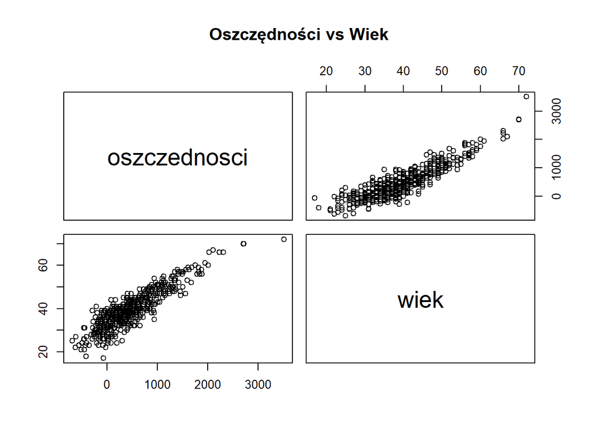

```r
pairs(oszczednosci ~ wiek, data = df, main="Oszczędności vs Wiek")
```

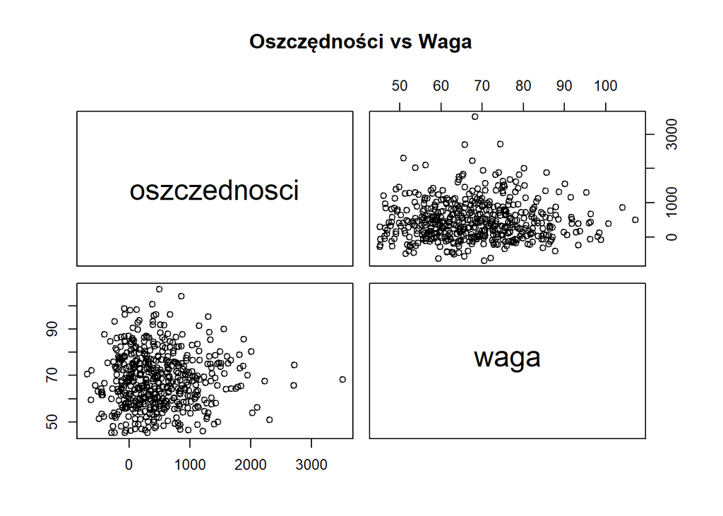

```r
pairs(oszczednosci ~ waga, data = df, main="Oszczędności vs Waga")
```

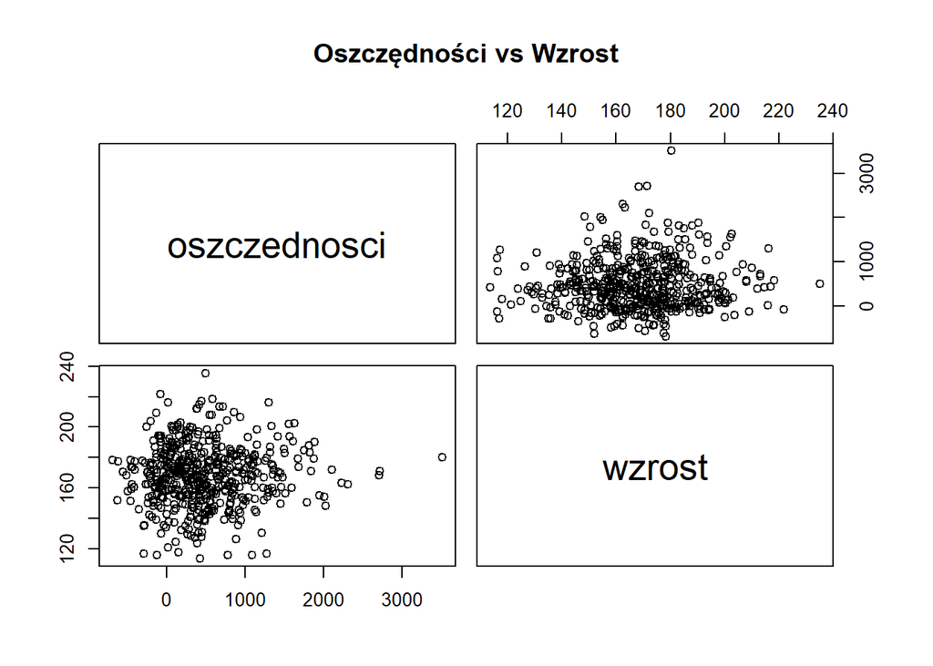

```r
pairs(oszczednosci ~ wzrost, data = df, main="Oszczędności vs Wzrost")
```

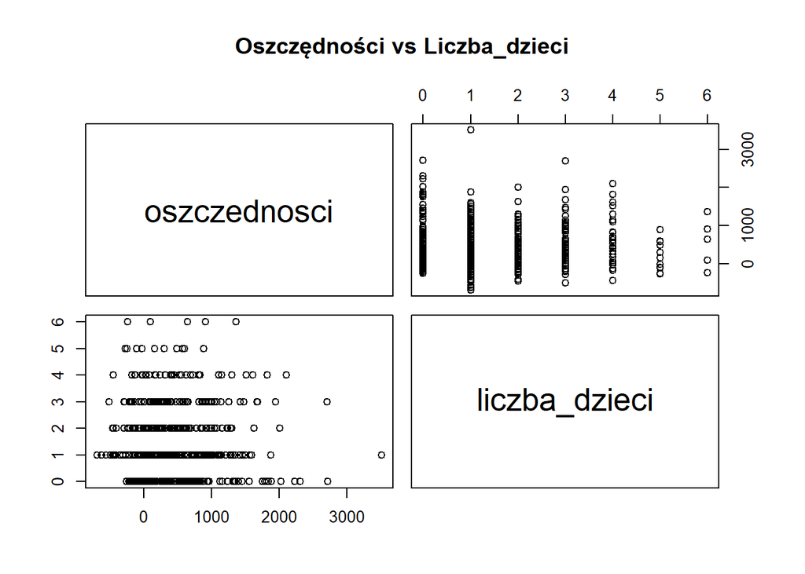

```r
pairs(oszczednosci ~ liczba_dzieci, data = df, main="Oszczędności vs Liczba_dzieci")
```

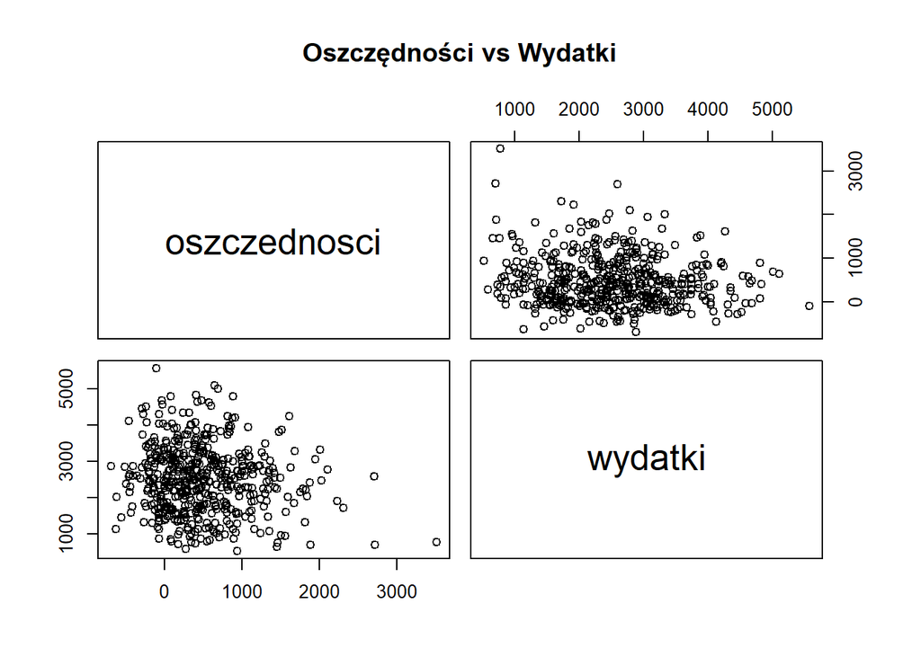

```r
pairs(oszczednosci ~ wydatki, data = df, main="Oszczędności vs Wydatki")
```

# b)

Box-plot

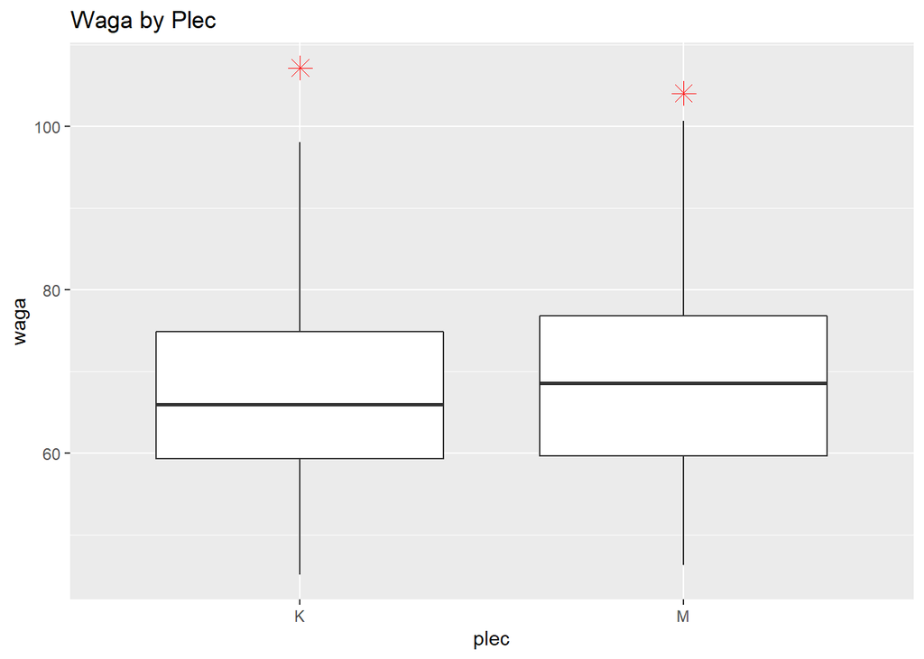

```r
ggplot(df.nonan, aes(plec,waga)) +
  geom_boxplot(outlier.colour="red", outlier.shape=8,
                  outlier.size=4)+labs(title = "Waga by Plec")
```

# c) Pie chart

```r
count.by.liczba_dzieci <- df %>% count(liczba_dzieci, sort = TRUE)

slices <- c(count.by.liczba_dzieci$n)
lbls <- count.by.liczba_dzieci$liczba_dzieci

pct <- round(slices/sum(slices)*100)
pct
```

```
## [1] 32 25 20 13  7  2  1
```

```r
lbls <- paste(lbls," dzieci: ", pct)
lbls <- paste(lbls,"%",sep="")
slices
```

```
## [1] 161 125  99  63  35  11   6
```

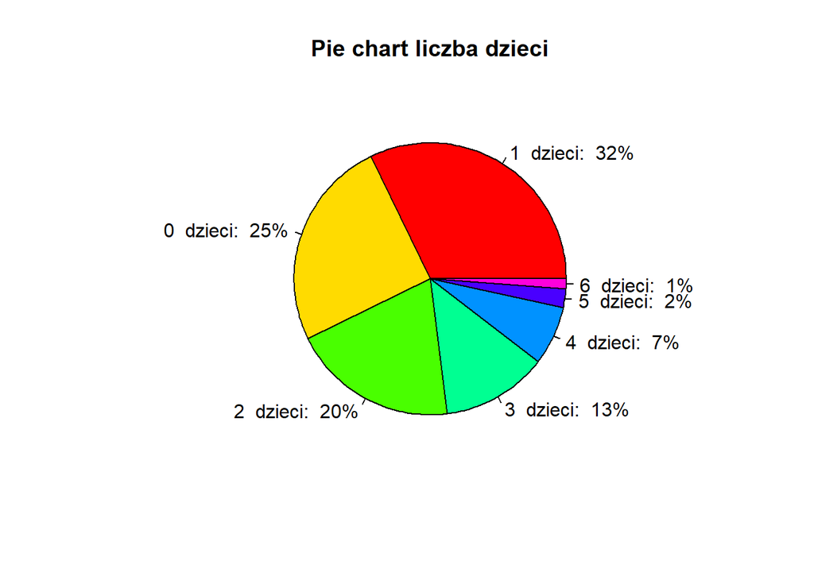

```r
pie(slices,labels = lbls, col=rainbow(length(lbls)),
   main="Pie chart liczba dzieci")
```

# d)

Histogramy zmiennych ilościowych

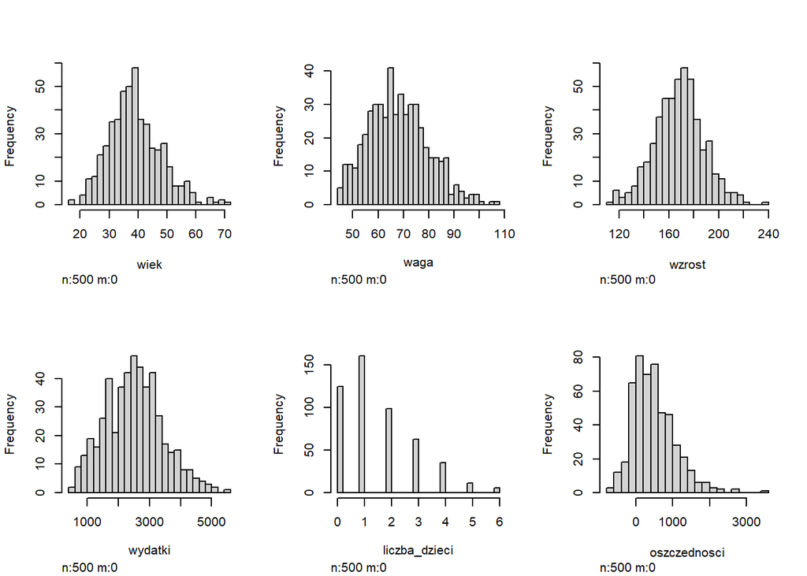

```r
hist.data.frame(df[c('wiek','waga','wzrost','wydatki','liczba_dzieci','oszczednosci')])
```

## 3.

# a)

Test u0 = 170 Skorzystamy z: Test istotności dla wartości średniej (B)- wykład 2 slajd 28 Założenia testu: popluacja o rozkładzie normalnym, średnia i wariancja nieznane. Zatem musimy sprawdzić, czy populacja ma rozkład normalny, pozostałe założenia spełnione.

Przywołajmy zatem ponownie histogram wzrostu.

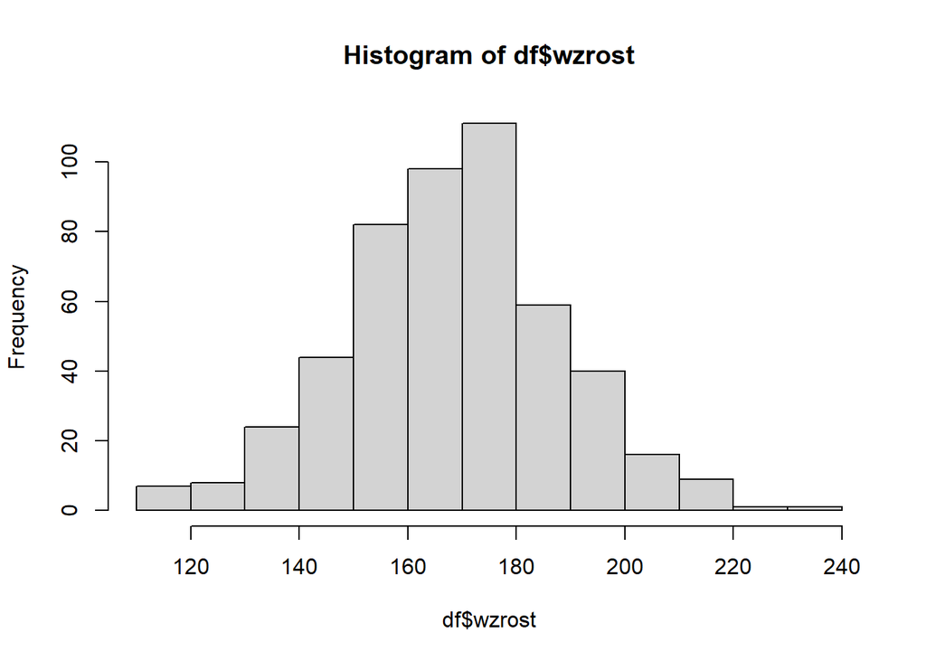

```r
hist(df$wzrost)
```

a także qqplot…

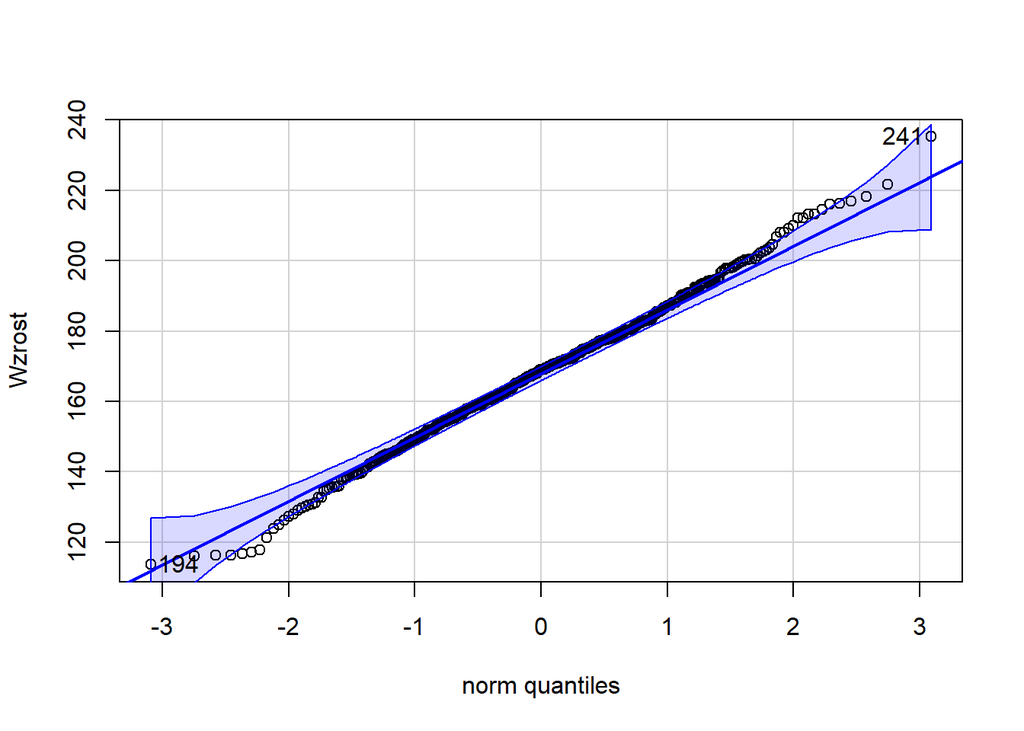

```
## [1] 241 194
```

```r
qqPlot(df$wzrost, ylab="Wzrost")
```

Na podstawie wykresów przyjmujemy, że populacja ma rozkład normalny. Zatem założenia spełnione, pora na test…

```r
#

u0 <- 170

wzrost <- df$wzrost
avg.wzrost <- mean(wzrost)

n <- nrow(df) # liczba obserwacji


Sn <- sqrt(1/n*sum((wzrost - avg.wzrost)^2)) # odchylenie standardowe z próby

stat.T <- ( avg.wzrost - u0 ) / Sn * sqrt(n-1)

#stat.T # to nasza statystyka testowa i faktycznie zgadza się z poniższym testem

#t.test(wzrost,alternative = c("less"),mu = u0)

p.value1 <- t.test(wzrost,alternative = c("less"),mu = u0)$p.value

cat("Wartość p-value pierwszego testu ", p.value1)
```

```
## Wartość p-value pierwszego testu  0.01948702
```

```r
# "Przyjmijmy poziom istotności 0.05, to p-value wyszło mniejsze, zatem odrzucamy hipotezę zerową o tym, że średni wzrost to 170.
```

# b)

Ponieważ mediana rozkładu normalnego jest równa wartości średniej rozkładu normalnego to możemy zrobić analogiczny test dla u0 = 165…

```r
u0 <- 165

stat.T <- ( avg.wzrost - u0 ) / Sn * sqrt(n-1)

#stat.T # ponownie to nasza statystyka testowa i faktycznie zgadza się z poniższym testem

#t.test(wzrost,alternative = c("less"),mu = u0)

p.value2 <- t.test(wzrost,alternative = c("less"),mu = u0)$p.value

cat("Wartość p-value drugiego testu ", p.value2)
```

```
## Wartość p-value drugiego testu  0.9998363
```

W przypadku drugiego testu założenia są identyczne i również są spełnione.

## 4.

# a)

Podobnie jak wcześniej musimy sprawdzić założenie o tym, że populacja ma rozkład normalny, pozostałe założenia o tym, że nie znamy średniej i mediany oczywiście spełnione…

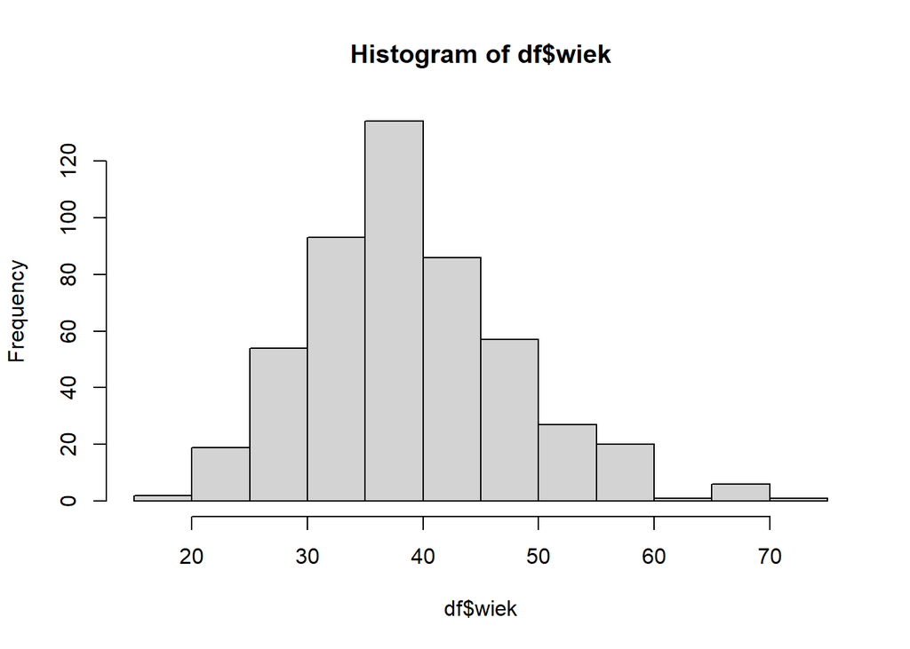

```r
hist(df$wiek)
```

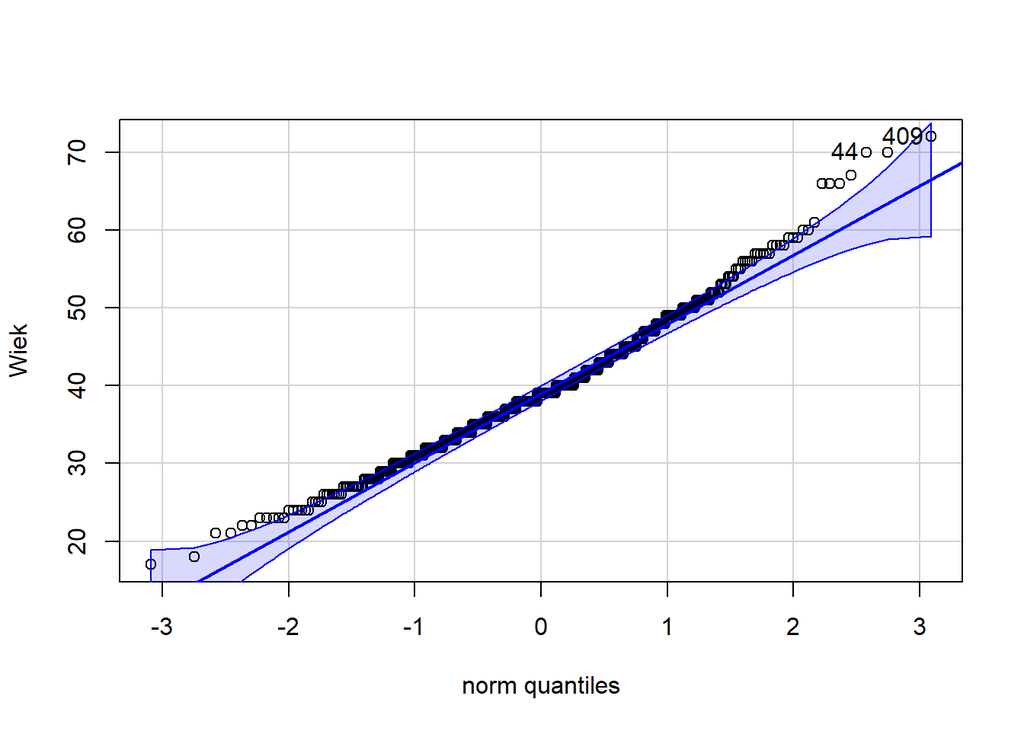

```
## [1] 409  44
```

```r
qqPlot(df$wiek, ylab="Wiek")
```

Ponownie możemy przyjąć, że mamy do czynienia z populacją o rozkładzie normalym…

```r
wiek <- df$wiek
avg.wiek <- mean(wiek)

Sn <- sqrt(1/n*sum((wiek - avg.wiek)^2))

error <- qt(0.995,df=n-1)*Sn/sqrt(n-1)

left.u <- avg.wiek-error
right.u <- avg.wiek+error

cat("Przedział ufności dla wartości oczekiwanej to  (", left.u, ",",right.u,").")
```

```
## Przedział ufności dla wartości oczekiwanej to  ( 38.446 , 40.522 ).
```

```r
left.sd = sqrt(n/qchisq(0.995, df=n-1))*Sn
right.sd = sqrt(n/qchisq(0.005, df=n-1))*Sn

cat("Przedział ufności dla odchylenia standardowego to  (", left.sd, ",",right.sd,").")
```

```
## Przedział ufności dla odchylenia standardowego to  ( 8.296544 , 9.768113 ).
```

# b)

```r
cat("Przedział ufności dla kwantyla 0.25 to: ",as.numeric(jmuOutlier::quantileCI(x=wiek, probs=0.25, conf.level=0.99)[1,c("lower","upper")]),"\n")
```

```
## Przedział ufności dla kwantyla 0.25 to:  32 35
```

```r
cat("Przedział ufności dla kwantyla 0.5 to: ",as.numeric(jmuOutlier::quantileCI(x=wiek, probs=0.5, conf.level=0.99)[1,c("lower","upper")]),"\n")
```

```
## Przedział ufności dla kwantyla 0.5 to:  38 40
```

```r
cat("Przedział ufności dla kwantyla 0.75 to: ",as.numeric(jmuOutlier::quantileCI(x=wiek, probs=0.75, conf.level=0.99)[1,c("lower","upper")]),"\n")
```

```
## Przedział ufności dla kwantyla 0.75 to:  43 47
```

## 5.

# a)

Omówimy zmienną waga.

```r
df.wzwiazku <- df[df$stan_cywilny == TRUE, ]
df.niewzwiazku <- df[df$stan_cywilny == FALSE, ]
head(df.wzwiazku)
```

```
##    wiek waga wzrost plec stan_cywilny liczba_dzieci       budynek wydatki
## 2    37 63.9 145.00    M         TRUE             6  wielka_plyta 4041.86
## 3    41 50.2 145.03    K         TRUE             2    apartament 3853.45
## 6    49 59.4 151.86    K         TRUE             2          loft 1967.87
## 9    38 64.1 138.37    K         TRUE             5  wielka_plyta 3382.54
## 12   27 84.4 192.40    M         TRUE             4  wielka_plyta 1875.45
## 13   46 63.4 164.44    K         TRUE             4 jednorodzinny 3914.56
##    oszczednosci
## 2         96.84
## 3        312.68
## 6       1241.98
## 9        486.20
## 12        38.54
## 13       830.16
```

Do testu 2 średnich potrzebujemy, aby populacja była rozkładu normalnego, konieczna jest również równość wariancji. Sprawdźmy najpierw czy zmienna waga obu populacji ma rozklad normalny…

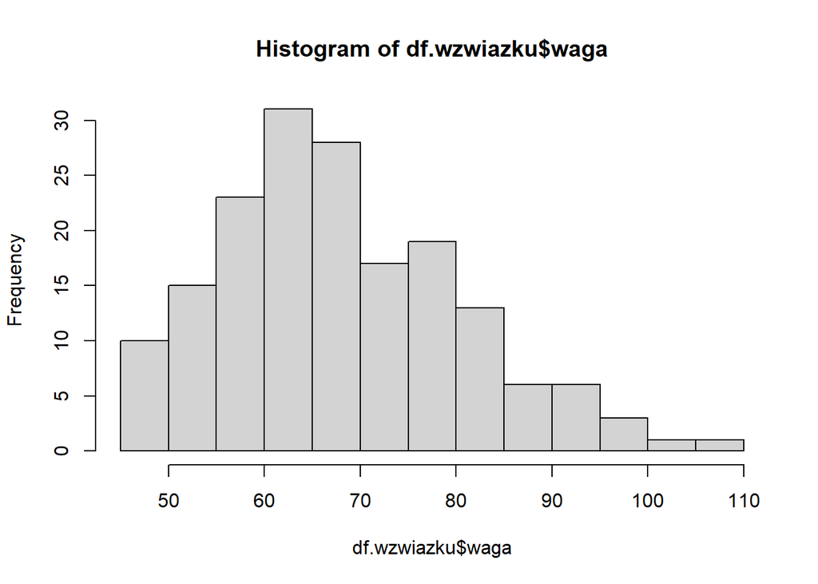

```r
hist(df.wzwiazku$waga)
```

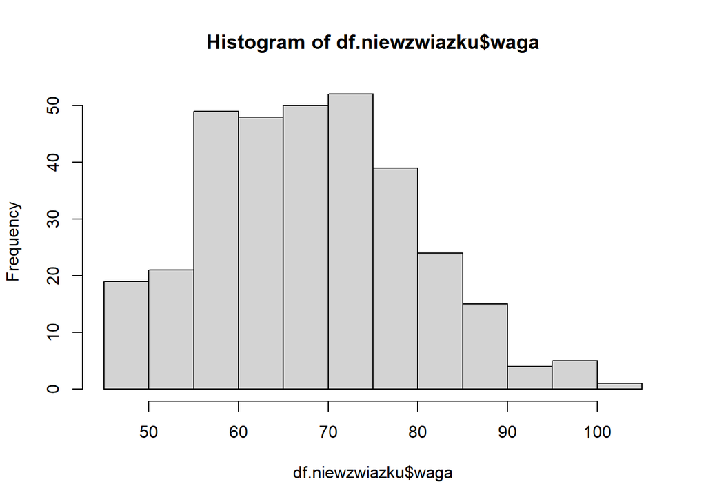

```r
hist(df.niewzwiazku$waga)
```

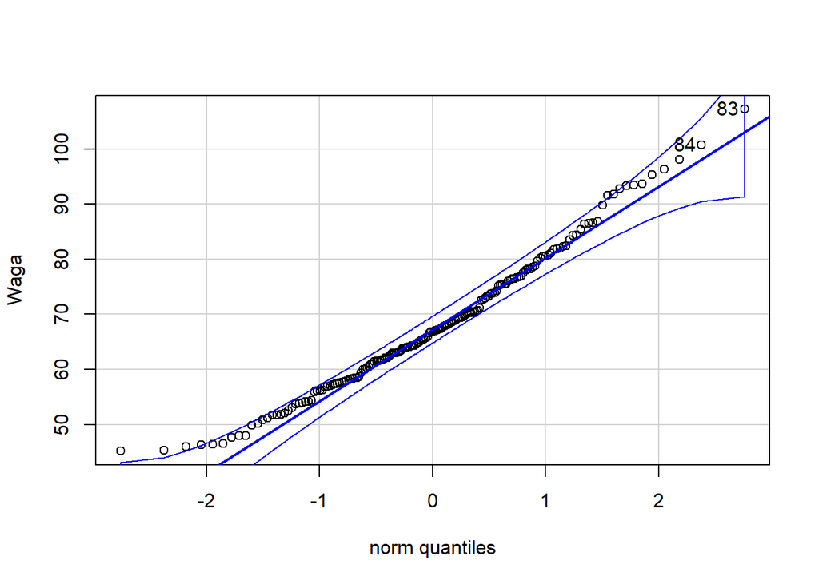

```
## [1] 83 84
```

```r
qqPlot(df.wzwiazku$waga, ylab="Waga")
```

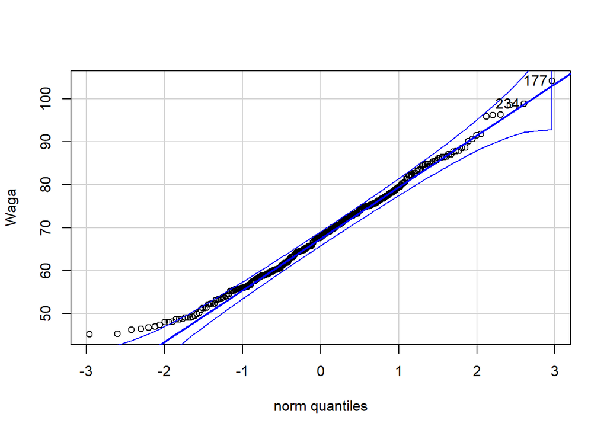

```
## [1] 177 234
```

```r
qqPlot(df.niewzwiazku$waga, ylab="Waga")
```

Na podstawie wyników przyjmujemy, że mają rozkłady normalne.

Teraz dokonamy testu równości wariancji. H_0 - wariancje są równe, H_1 - wariancje nie są równe

```r
var.test(x = df.wzwiazku$waga, y = df.niewzwiazku$waga, alternative = "two.sided")
```

```
##
##  F test to compare two variances
##
## data:  df.wzwiazku$waga and df.niewzwiazku$waga
## F = 1.1891, num df = 172, denom df = 326, p-value = 0.1858
## alternative hypothesis: true ratio of variances is not equal to 1
## 95 percent confidence interval:
##  0.920046 1.553520
## sample estimates:
## ratio of variances
##           1.189133
```

p-value > 0.01 więc nie odrzucamy hipotezy o równości wariancji.

Teraz bieżemy się za test t równości średnich…

```r
t.test(df.wzwiazku$waga, df.niewzwiazku$waga, var.equal = TRUE)
```

```
##
##  Two Sample t-test
##
## data:  df.wzwiazku$waga and df.niewzwiazku$waga
## t = -0.087766, df = 498, p-value = 0.9301
## alternative hypothesis: true difference in means is not equal to 0
## 95 percent confidence interval:
##  -2.277180  2.082434
## sample estimates:
## mean of x mean of y
##  67.96532  68.06269
```

p-value >> 0.01 zatem nie odrzucamy hipotezy zerowej o tym, że średnia waga dla obu grup jest równa.

# b)

H_0 - zmienna waga nie jest zależna od zmiennej wzrost, H_1 - waga jest zależna od wzrostu

Współczynnik korelacji Pearsona mierzy relację między dwiema zmiennymi ciągłymi… Jego założenia: 1. obie zmienne ciągłe | ok 2. Między dwiema zmiennymi istnieje liniowa zależność. 3. Brak znaczących wartości odstających 4. Zmienne mają rozkład normalny | ok, to wiemy z poprzednich rozważań

To odnieśmy się do 2 i 3:

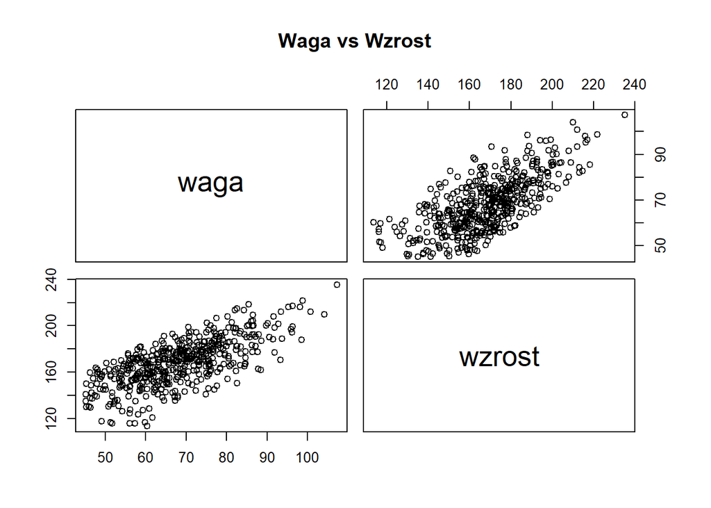

```r
pairs(waga ~ wzrost, data = df, main="Waga vs Wzrost")
```

Widzimy, że punkty na scatter plocie faktycznie układają się w pewnym stopniu w linię, a także nie ma wartości, które w dużym stopniu starały się odbiegać od naszej “prawie linii”.

Zatem przejdźmy do testu…

```r
cor.test(df$waga, df$wzrost, method="pearson")
```

```
##
##  Pearson's product-moment correlation
##
## data:  df$waga and df$wzrost
## t = 21.768, df = 498, p-value < 0.00000000000000022
## alternative hypothesis: true correlation is not equal to 0
## 95 percent confidence interval:
##  0.6503935 0.7406028
## sample estimates:
##       cor
## 0.6982599
```

Ponieważ p-value << 0.01 to odrzucamy hipotezę zerową o braku zależności.

# c)

Porównajmy zmienne budynek i stan_cywilny Skorzystamy z testu chi-square. Test ten służy do określenia, czy dwie zmienne kategoryczne są niezależne. Założenia: 1. Obie zmienne kategoryczne | ok 2. Oczekiwana wartość komórek powinna wynosić 5 lub więcej w co najmniej 80% komórek: 3. Komórki w tabeli kontyngencji wzajemnie się wykluczają.

Sprawdźmy 2 i 3:

```r
con_table <- table(df$stan_cywilny, df$budynek)
con_table
```

```
##
##         apartament jednorodzinny kamienica loft wielka_plyta
##   FALSE         32           127        61   40           67
##   TRUE          22            60        44   14           33
```

Zgadza się. Przeprowadźmi test chi-square: H_0 - nie ma zależności pomiędzy zmiennymi, H_1 - jest zależność pomiędzy zmiennymi

```r
chisq.test(df$budynek, df$stan_cywilny)
```

```
##
##  Pearson's Chi-squared test
##
## data:  df$budynek and df$stan_cywilny
## X-squared = 5.807, df = 4, p-value = 0.214
```

p-value > 0.01, zatem nie odrzucamy hipotezy zerowej o tym, że nie ma zależności.

# d) Test Kołmogorowa-Smirnowa dla 2 prób dla zmiennej oszczednosci vs exp(3)

Założenia: 1. Test jest dokładny tylko dla zmiennych ciągłych. | ok

H_0 - oszczednosci mają rozklad exp z parametrem 3, H_1 - oszczednosci nie maja rozkladu exp z parametrem 3

```r
sample.exp.distribution <- rexp(600, rate = 3) # tworzymy wektor z rozkładu wykładniczego z parametrem 3

ks.test(df$oszczednosci, sample.exp.distribution)
```

```
##
##  Two-sample Kolmogorov-Smirnov test
##
## data:  df$oszczednosci and sample.exp.distribution
## D = 0.802, p-value < 0.00000000000000022
## alternative hypothesis: two-sided
```

p <<< 0.01, zatem odrzucamy hipotezę zerową.

## 6.

Model regresji

```r
linear.regression <- lm(oszczednosci ~ ., df)
summary(linear.regression)
```

```
##
## Call:
## lm(formula = oszczednosci ~ ., data = df)
##
## Residuals:
##     Min      1Q  Median      3Q     Max
## -307.64  -60.13   -1.69   58.06  462.98
##
## Coefficients:
##                        Estimate Std. Error t value             Pr(>|t|)
## (Intercept)          -873.59106   58.76098 -14.867 < 0.0000000000000002 ***
## wiek                   63.94258    0.56712 112.750 < 0.0000000000000002 ***
## waga                    3.94409    0.56935   6.927      0.0000000000149 ***
## wzrost                 -2.38464    0.35204  -6.774      0.0000000000394 ***
## plecM                   1.38069    9.63179   0.143                0.886
## stan_cywilnyTRUE       -4.61252   12.91187  -0.357                0.721
## liczba_dzieci         151.60355    6.15687  24.623 < 0.0000000000000002 ***
## budynekjednorodzinny -182.07031   16.43991 -11.075 < 0.0000000000000002 ***
## budynekkamienica     -305.63144   17.89020 -17.084 < 0.0000000000000002 ***
## budynekloft          -338.47001   25.14078 -13.463 < 0.0000000000000002 ***
## budynekwielka_plyta  -564.26015   20.59225 -27.402 < 0.0000000000000002 ***
## wydatki                -0.39593    0.01057 -37.455 < 0.0000000000000002 ***
## ---
## Signif. codes:  0 '***' 0.001 '**' 0.01 '*' 0.05 '.' 0.1 ' ' 1
##
## Residual standard error: 102 on 450 degrees of freedom
##   (38 obserwacji zostało skasowanych z uwagi na braki w nich zawarte)
## Multiple R-squared:  0.9673, Adjusted R-squared:  0.9665
## F-statistic:  1209 on 11 and 450 DF,  p-value: < 0.00000000000000022
```

Gdzie w kolumnie Estimate widzimy wyestymowane współczynniki przy danych zmiennych.

# a)

Czy transformacja zmiennych jest konieczna?

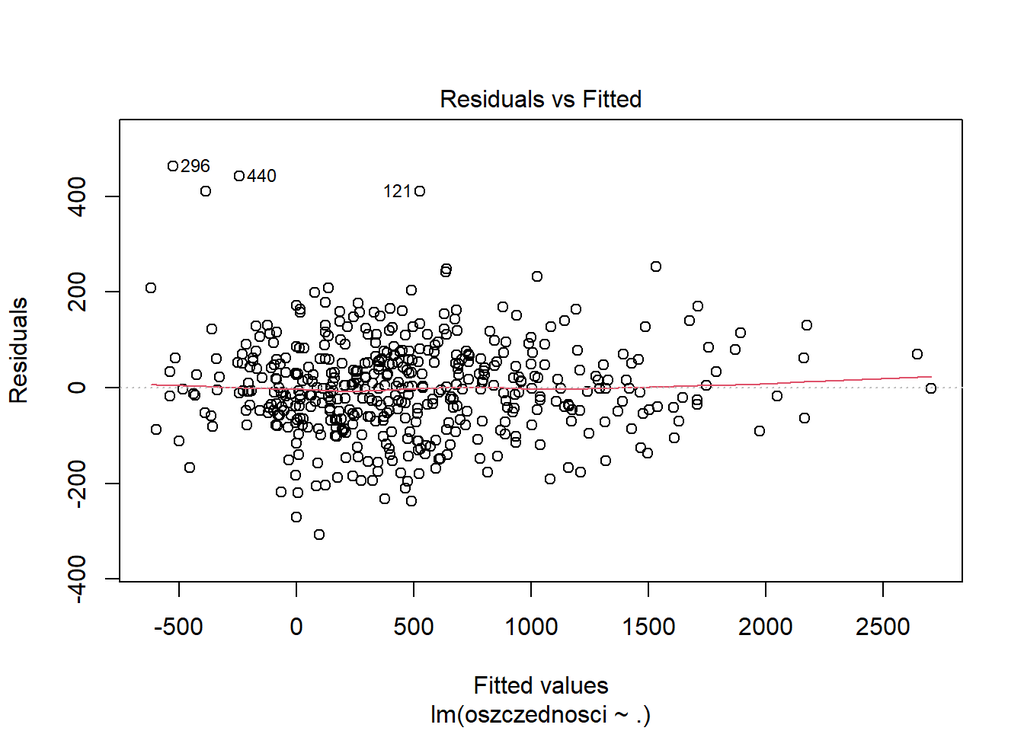

```r
plot(linear.regression, which = 1)
```

Na pierwszym wykresie widzimy czerwoną linię oznaczającą trend. Jest on liniowy, zatem nie ma potrzeby transformacji zmiennych objasniających.

Teraz przyjrzymy się zmiennej objaśnianej.

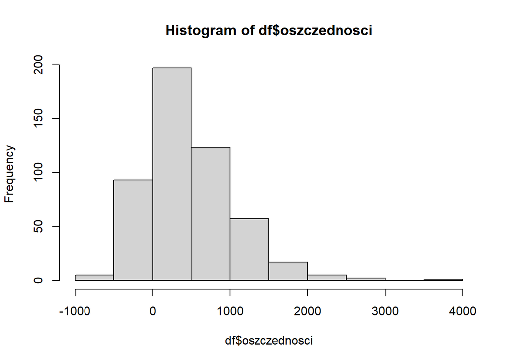

```r
hist(df$oszczednosci)
```

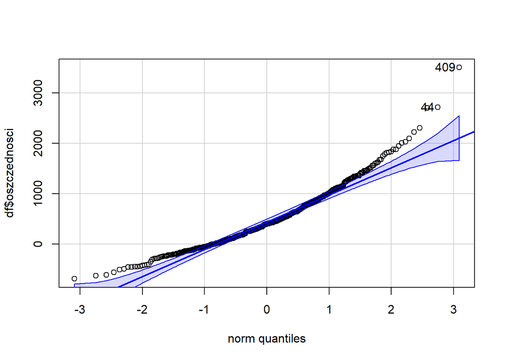

```
## [1] 409  44
```

```r
qqPlot(df$oszczednosci)
```

# b)

```r
linear.regression.rss <- deviance(linear.regression)
cat("RSS wynosi",linear.regression.rss,"\n\n")
```

```
## RSS wynosi 4681334
```

```r
linear.regression.rsquared <- summary(linear.regression)$r.squared

cat("R^2 wynosi",linear.regression.rsquared,"\n\n")
```

```
## R^2 wynosi 0.9672621
```

```r
cat("p-wartości: ","\n\n")
```

```
## p-wartości:
```

```r
summary(linear.regression)$coefficients[,4]
```

```
##          (Intercept)                 wiek                 waga
##         5.903953e-41         0.000000e+00         1.490112e-11
##               wzrost                plecM     stan_cywilnyTRUE
##         3.937286e-11         8.860806e-01         7.210861e-01
##        liczba_dzieci budynekjednorodzinny     budynekkamienica
##         2.061387e-85         2.256391e-25         8.459593e-51
##          budynekloft  budynekwielka_plyta              wydatki
##         5.900373e-35         5.816251e-98        2.193560e-140
```

```r
cat("\n\n","Oszacowania współczynników w modelu pełnym: ","\n\n")
```

```
##
##
##  Oszacowania współczynników w modelu pełnym:
```

```r
linear.regression$coefficients
```

```
##          (Intercept)                 wiek                 waga
##         -873.5910639           63.9425778            3.9440904
##               wzrost                plecM     stan_cywilnyTRUE
##           -2.3846402            1.3806850           -4.6125227
##        liczba_dzieci budynekjednorodzinny     budynekkamienica
##          151.6035490         -182.0703090         -305.6314445
##          budynekloft  budynekwielka_plyta              wydatki
##         -338.4700061         -564.2601455           -0.3959261
```

# c)

Stwórzmy modele bez poszczególnych zmiennych.

```r
lr.no.wiek <- lm(oszczednosci ~ .-wiek, df)
lr.no.waga <- lm(oszczednosci ~ .-waga, df)
lr.no.wzrost <- lm(oszczednosci ~ .-wzrost, df)
lr.no.plec <- lm(oszczednosci ~ .-plec, df)
lr.no.stan_cywilny <- lm(oszczednosci ~ .-stan_cywilny, df)
lr.no.liczba_dzieci <- lm(oszczednosci ~ .-liczba_dzieci, df)
lr.no.budynek <- lm(oszczednosci ~ .-budynek, df)
lr.no.wydatki <- lm(oszczednosci ~ .-wydatki, df)
```

Poszczególne p-wartości znamy z wcześniejszych rozważań, przyjrzyjmy się teraz zmianom w R^2:

```r
cat("zmiana R^2 dla zmiennej WIEK",linear.regression.rsquared-summary(lr.no.wiek)$r.squared,"\n")
```

```
## zmiana R^2 dla zmiennej WIEK 0.9248484
```

```r
cat("zmiana R^2 dla WAGA",linear.regression.rsquared-summary(lr.no.waga)$r.squared,"\n")
```

```
## zmiana R^2 dla WAGA 0.003491137
```

```r
cat("zmiana R^2 dla WZROST",linear.regression.rsquared-summary(lr.no.wzrost)$r.squared,"\n")
```

```
## zmiana R^2 dla WZROST 0.003338138
```

```r
cat("zmiana R^2 dla PLEC",linear.regression.rsquared-summary(lr.no.plec)$r.squared,"\n")
```

```
## zmiana R^2 dla PLEC 0.000001494907
```

```r
cat("zmiana R^2 dla STAN_CYWILNY",linear.regression.rsquared-summary(lr.no.stan_cywilny)$r.squared,"\n")
```

```
## zmiana R^2 dla STAN_CYWILNY 0.000009284059
```

```r
cat("zmiana R^2 dla LICZBA_DZIECI",linear.regression.rsquared-summary(lr.no.liczba_dzieci)$r.squared,"\n")
```

```
## zmiana R^2 dla LICZBA_DZIECI 0.04411006
```

```r
cat("zmiana R^2 dla BUDYNEK",linear.regression.rsquared-summary(lr.no.budynek)$r.squared,"\n")
```

```
## zmiana R^2 dla BUDYNEK 0.06279797
```

```r
cat("zmiana R^2 dla WYDATKI",linear.regression.rsquared-summary(lr.no.wydatki)$r.squared,"\n")
```

```
## zmiana R^2 dla WYDATKI 0.1020626
```

Zatem najmniejszą różnicę w R^2 dostajemy dla zmiennej płeć.

Sprawdźmy teraz RSS…

```r
cat("zmiana RSS dla zmiennej WIEK",(deviance(lr.no.wiek)-linear.regression.rss),"\n")
```

```
## zmiana RSS dla zmiennej WIEK 132247908
```

```r
cat("zmiana RSS dla zmiennej WAGA",(deviance(lr.no.waga)-linear.regression.rss),"\n")
```

```
## zmiana RSS dla zmiennej WAGA 499212.2
```

```r
cat("zmiana RSS dla zmiennej WZROST",(deviance(lr.no.wzrost)-linear.regression.rss),"\n")
```

```
## zmiana RSS dla zmiennej WZROST 477334.1
```

```r
cat("zmiana RSS dla zmiennej PLEC",(deviance(lr.no.plec)-linear.regression.rss),"\n")
```

```
## zmiana RSS dla zmiennej PLEC 213.7629
```

```r
cat("zmiana RSS dla zmiennej STAN_CYWILNY",(deviance(lr.no.stan_cywilny)-linear.regression.rss),"\n")
```

```
## zmiana RSS dla zmiennej STAN_CYWILNY 1327.566
```

```r
cat("zmiana RSS dla zmiennej LICZBA_DZIECI",(deviance(lr.no.liczba_dzieci)-linear.regression.rss),"\n")
```

```
## zmiana RSS dla zmiennej LICZBA_DZIECI 6307480
```

```r
cat("zmiana RSS dla zmiennej BUDYNEK",(deviance(lr.no.budynek)-linear.regression.rss),"\n")
```

```
## zmiana RSS dla zmiennej BUDYNEK 8979742
```

```r
cat("zmiana RSS dla zmiennej",(deviance(lr.no.wydatki)-linear.regression.rss),"\n")
```

```
## zmiana RSS dla zmiennej 14594351
```

Zatem najmniejszą różnicę w RSS dostajemy dla zmiennej płeć.

Także jak pamiętamy p-value było dla tej zmiennej najwyższe ( 0.886 ) w pełnym modelu , a zatem na podstawie powyższych rozważań stwierdzamy, że zmienną objaśniającą, którą można by z pełnego modelu odrzucić jest zmienna płeć.

# d)

W dalszych rozważaniach pozostańmy przy modelu bez zmiennej płeć…

```r
summary(lr.no.plec)
```

```
##
## Call:
## lm(formula = oszczednosci ~ . - plec, data = df)
##
## Residuals:
##     Min      1Q  Median      3Q     Max
## -306.83  -60.62   -1.79   58.67  463.67
##
## Coefficients:
##                        Estimate Std. Error t value             Pr(>|t|)
## (Intercept)          -872.88762   58.49209 -14.923 < 0.0000000000000002 ***
## wiek                   63.94122    0.56642 112.886 < 0.0000000000000002 ***
## waga                    3.94887    0.56776   6.955      0.0000000000124 ***
## wzrost                 -2.38524    0.35163  -6.783      0.0000000000370 ***
## stan_cywilnyTRUE       -4.83341   12.80566  -0.377                0.706
## liczba_dzieci         151.69318    6.11838  24.793 < 0.0000000000000002 ***
## budynekjednorodzinny -182.14265   16.41431 -11.097 < 0.0000000000000002 ***
## budynekkamienica     -305.65338   17.87011 -17.104 < 0.0000000000000002 ***
## budynekloft          -338.69765   25.06331 -13.514 < 0.0000000000000002 ***
## budynekwielka_plyta  -564.40762   20.54419 -27.473 < 0.0000000000000002 ***
## wydatki                -0.39600    0.01055 -37.548 < 0.0000000000000002 ***
## ---
## Signif. codes:  0 '***' 0.001 '**' 0.01 '*' 0.05 '.' 0.1 ' ' 1
##
## Residual standard error: 101.9 on 451 degrees of freedom
##   (38 obserwacji zostało skasowanych z uwagi na braki w nich zawarte)
## Multiple R-squared:  0.9673, Adjusted R-squared:  0.9665
## F-statistic:  1332 on 10 and 451 DF,  p-value: < 0.00000000000000022
```

Gdzie w pierwszej kolumnie Estimate wyestymowane współczynniki przy danych zmiennych.

Założenia: 1. Istnieje liniowa zależność między zmiennymi objaśniającymi a zmienną objaśnianą. 2. Zmienne objaśniające są niezależne i obserowawane z pomijalnym błędem. 3. Średnia wartość residuów wynosi 0. 4. Residua są o stałej wariancji. 5. Residua są niezależne. ( to założenie wymaga od nas wiedzy o tym czy dane zostały zasymulowane w sposób niezalażny, zatem tego nie zweryfikujemy )

Zatem sprawdźmy…

Najpierw 1 i 3:

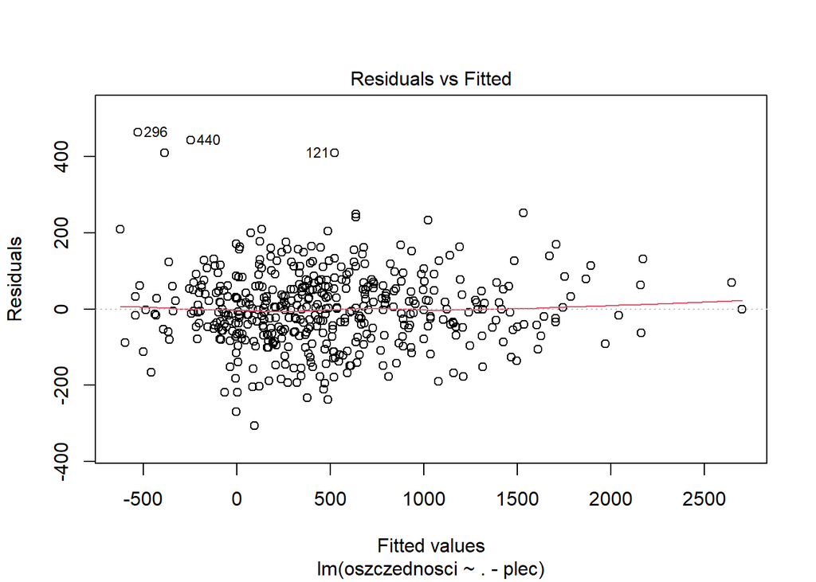

```r
plot(lr.no.plec, which=1)
```

Widzimy, że czerwona linia jest położona niemal poziomo na 0, dzięki czemu stwierdzamy, że istnieje liniowa zależność oraz średnia wartość redisuów faktycznie wynosi 0.

```r
durbinWatsonTest(lr.no.plec)
```

```
##  lag Autocorrelation D-W Statistic p-value
##    1    -0.006336873      2.012017   0.862
##  Alternative hypothesis: rho != 0
```

Ponieważ p-value >> 0.05, to nie odrzucamy hipotezy zerowej.

Teraz 4…

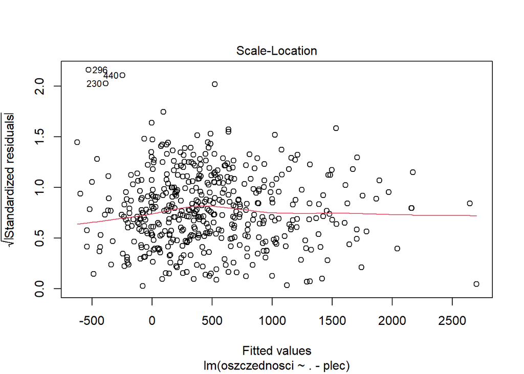

```r
plot(lr.no.plec, which=3)
```

Residua są mniej więcej równomiernie rozłożone wokół czerwonej linii, co może świadczyć o stałej wariancji.

# e)

Wykres zależności reszt od zmiennej objaśnianej już omawialiśmy

Wykres reszt studentyzowanych i dźwigni:

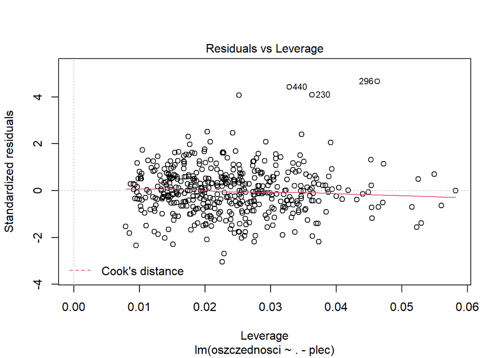

```r
plot(lr.no.plec, which=5)
```

## Bibliografia:

- Statystyczna analiza danych (Mat) 21/22.L
- towardsdatascience
- influentialpoints
- wikipedia
- stats.stackexchange
- rcodumentation
- statology
- medium
- dataanalytics
- statistics.laerd
- youtube channel: MarinStatsLectures-R Programming & Statistics
- godatadrive